# Презентация по второму этапу индивидуального проекта

Архитектура компьютеров и операционные системы

Дауд А.

Российский университет дружбы народов, Москва, Россия

21 марта 2025

# Информация

## Докладчик

# Цель работы

Изучение размещения посты на сайте.

# Задание

1. Добавлять данные:
   1. Разместить фотографию владельца сайта
   2. Разместить краткое описание владельца сайта
   3. Добавить информацию об интересах
   4. Добавить информацию об образовании
2. Сделать пост по прошедшей неделе
3. Сделать пост по теме “Управление версиями GIT”

## Добавление данных

### Разместить фотографию владельца сайта

Я запускаю hugo в каталоге ~/work/blog/, чтобы начать создание сайта:

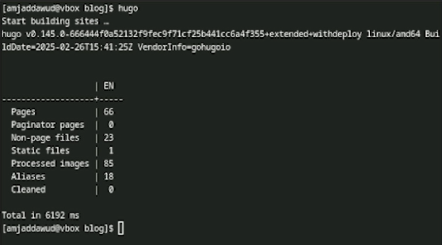

Запуск hugo

### Разместить фотографию владельца сайта

Запускаю hugo server, чтобы получить локальный хост-сайт, где я могу видеть вносимые мной изменения:

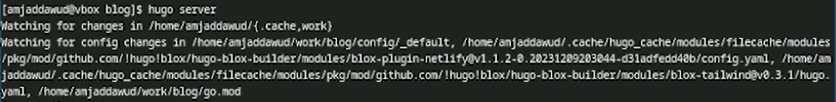

Запуск hugo server

### Разместить фотографию владельца сайта

Заменяю avatar.jpg на свою фотографию и она устанавливается автоматический:

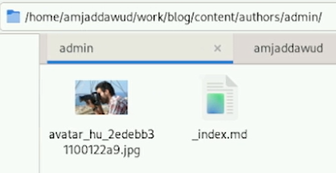

Замена фотографии

### Разместить краткое описание владельца сайта

Далее с помощью gedit я редактирую файл index.md, который ноходится в ~/work/blog/content/author и добавляю свою краткую биографию:

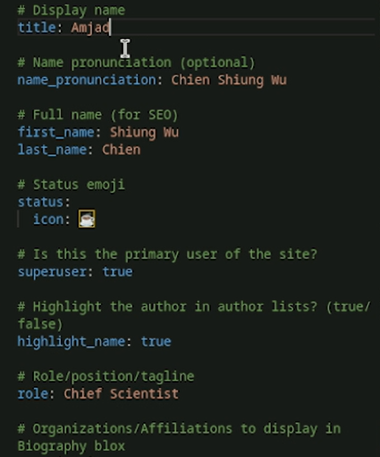

Файл с информацией владельца

### Разместить краткое описание владельца сайта

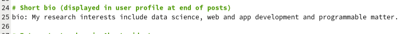

Краткая биография

### Разместить краткое описание владельца сайта

Проверяю изменении на сайте:

[figure not shown]

Проверка на сайте

### Добавить информацию об образовании

Также изменяю информацию об образовании:

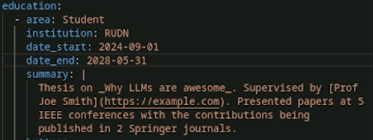

Образование

## Пост по прошедшей неделе

Я перехожу в катклог ~/work/blog/content/post и создаю новую папку. Создаю файл index.md и вставляю фотографию featured.jpg:

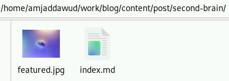

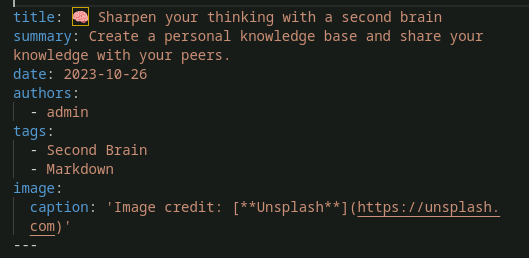

## Пост по теме “Управление версиями GIT”

Создаю ещё одну новую папку в ~/work/blog/content/post. Создаю файл index.md и вставляю фотографию featured.jpg:

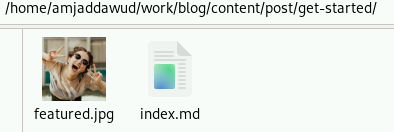

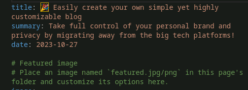

## Пост по теме “Управление версиями GIT”

После сохранения изменении, я отправляю все на github:

[figure not shown]

# Выводы

При выполнении данной работы, я освоила размещение посты на сайте по шаблону hugo.